# PeerGradedAssignment

csanchez

September 9, 2019

## Background

Using devices such as Jawbone Up, Nike FuelBand, and Fitbit it is now possible to collect a large amount of data about personal activity relatively inexpensively. These type of devices are part of the quantified self movement - a group of enthusiasts who take measurements about themselves regularly to improve their health, to find patterns in their behavior, or because they are tech geeks. One thing that people regularly do is quantify how much of a particular activity they do, but they rarely quantify how well they do it. In this project, the goal will be to use data from accelerometers on the belt, forearm, arm, and dumbell of 6 participants. They were asked to perform barbell lifts correctly and incorrectly in 5 different ways. More information is available from the website here: http://groupware.les.inf.puc-rio.br/har

Six young healthy participants were asked to perform one set of 10 repetitions of the Unilateral Dumbbell Biceps Curl in five different fashions:

- Class A - exactly according to the specification
- Class B - throwing the elbows to the front
- Class C - lifting the dumbbell only halfway
- Class D - lowering the dumbbell only halfway
- Class E - throwing the hips to the front

Class A corresponds to the specified execution of the exercise, while the other 4 classes correspond to common mistakes. Participants were supervised by an experienced weight lifter to make sure the execution complied to the manner they were supposed to simulate. The exercises were performed by six male participants aged between 20-28 years, with little weight lifting experience. Researchers made sure that all participants could easily simulate the mistakes in a safe and controlled manner by using a relatively light dumbbell (1.25kg).

## Load the Data

The training data for this project are available here:

- https://d396qusza40orc.cloudfront.net/predmachlearn/pml-training.csv

The test data are available here:

- https://d396qusza40orc.cloudfront.net/predmachlearn/pml-testing.csv

The data for this project come from this source: http://groupware.les.inf.puc-rio.br/har.

## Clean data

The columns with a lot of missing values are removed. And columns not representative for what we’re trying to predict are removed to (timestamp, username, etc).

We are only interested in the columns related to the sensors (gyroscope, accelerometer).

```r
# remove columns
training <- training[,-1]
training <- training[,-grep('kurtosis_', colnames(training))]
training <- training[,-grep('var_', colnames(training))]
training <- training[,-grep('avg_', colnames(training))]
training <- training[,-grep('stddev_', colnames(training))]
training <- training[,-grep('min_', colnames(training))]
training <- training[,-grep('max_', colnames(training))]
training <- training[,-grep('skewness_', colnames(training))]
training <- training[,-grep('amplitude_', colnames(training))]
training <- training[,-grep('time', colnames(training))]
training <- training[,-grep('total_', colnames(training))]
training <- training[,-grep('window', colnames(training))]
training <- training[,-grep('user_name', colnames(training))]
```

## Model Development

### Split training and testing data sets

We use the 70% of the data for the training data set and the remaining 30% for testing purposes

```r
set.seed(998)
inTraining <- createDataPartition(training$classe, p = .70, list = FALSE)
training <- training[ inTraining,]
testing  <- training[-inTraining,]
```

### Cross validations and model training

The Generalized Boosted Regression Model (GBM) is going to be fitted with the training data. GBM constructs a forward stage-wise additive model by implementing gradient descent in function space

The resampling method is a 6-fold-cross-validation

The accuracy in the training data is close to 95%. Where the final values used for the model are n.trees = 150, interaction.depth = 3, shrinkage = 0.1 and n.minobsinnode = 10.

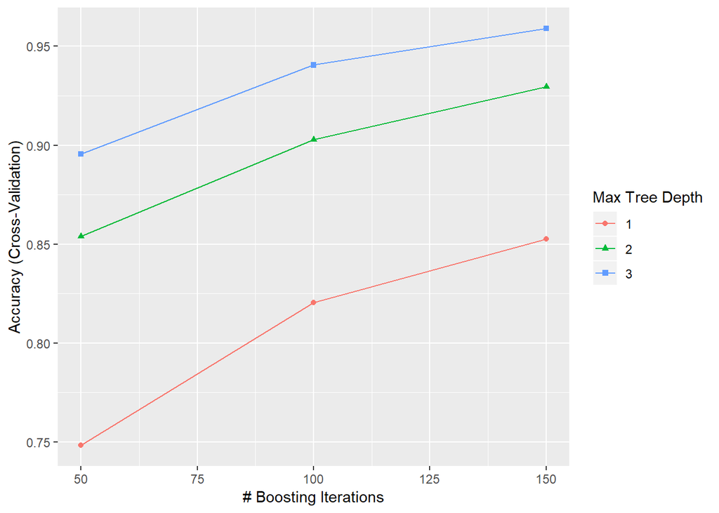

```r
control <- trainControl(method='cv', 6)

set.seed(898)
gbmFit <- train(classe ~ ., data = training,
                 method = "gbm",
                 trControl = control,
                 verbose = FALSE)

ggplot(gbmFit)
```

```r
gbmFit
```

```
## Stochastic Gradient Boosting
##
## 13737 samples
##    48 predictor
##     5 classes: 'A', 'B', 'C', 'D', 'E'
##
## No pre-processing
## Resampling: Cross-Validated (6 fold)
## Summary of sample sizes: 11446, 11447, 11448, 11448, 11449, 11447, ...
## Resampling results across tuning parameters:
##
##   interaction.depth  n.trees  Accuracy   Kappa
##   1                   50      0.7481976  0.6806050
##   1                  100      0.8203395  0.7726962
##   1                  150      0.8526611  0.8135587
##   2                   50      0.8539715  0.8149644
##   2                  100      0.9028898  0.8771135
##   2                  150      0.9296779  0.9110104
##   3                   50      0.8956098  0.8678286
##   3                  100      0.9405967  0.9248214
##   3                  150      0.9590144  0.9481491
##
## Tuning parameter 'shrinkage' was held constant at a value of 0.1
##
## Tuning parameter 'n.minobsinnode' was held constant at a value of 10
## Accuracy was used to select the optimal model using the largest value.
## The final values used for the model were n.trees = 150,
##  interaction.depth = 3, shrinkage = 0.1 and n.minobsinnode = 10.
```

### Model performance in the testing set

In order to validate the accuracy of the previusly fitted model is necessary to demonstrate tha the model predicts well in new data.

The accuracy on new data is close to 97%

```r
pred <- predict(gbmFit, testing)

confusionMatrix(pred, as.factor(testing$classe))
```

```
## Confusion Matrix and Statistics
##
##           Reference
## Prediction    A    B    C    D    E
##          A 1168   17    0    1    1
##          B    6  763   16    1    5
##          C    0   14  702   14    1
##          D    2    0    4  643    9
##          E    2    0    3    7  736
##
## Overall Statistics
##
##                Accuracy : 0.975
##                  95% CI : (0.9697, 0.9795)
##     No Information Rate : 0.2863
##     P-Value [Acc > NIR] : < 2.2e-16
##
##                   Kappa : 0.9683
##
##  Mcnemar's Test P-Value : NA
##
## Statistics by Class:
##
##                      Class: A Class: B Class: C Class: D Class: E
## Sensitivity            0.9915   0.9610   0.9683   0.9655   0.9787
## Specificity            0.9935   0.9916   0.9914   0.9957   0.9964
## Pos Pred Value         0.9840   0.9646   0.9603   0.9772   0.9840
## Neg Pred Value         0.9966   0.9907   0.9932   0.9933   0.9952
## Prevalence             0.2863   0.1930   0.1762   0.1618   0.1827
## Detection Rate         0.2838   0.1854   0.1706   0.1563   0.1789
## Detection Prevalence   0.2885   0.1922   0.1776   0.1599   0.1818
## Balanced Accuracy      0.9925   0.9763   0.9799   0.9806   0.9876
```

## Validate results

The model is validated against this set: https://d396qusza40orc.cloudfront.net/predmachlearn/pml-testing.csv

```r
predict(gbmFit, validation[, colnames(training[,-49])])
```

```
##  [1] B A B A A E D B A A B C B A E E A B B B
## Levels: A B C D E
```